# Praca domowa 2

Yauheni Butsialevich

## Dane

Dane wykorzystane w Pracy domowej 2 dotyczą wyników egzaminów z 3 umiejętności: czytania, pisania i operacji matematycznych. Dodatkowo dostępne są podstawowe informacje o studentach i ich rodzicach. Opis wszystkich kolumn znajduje się również w pliku `README.md`.

| Zmienna | Opis |
| --- | --- |
| **gender** | płeć |
| **race.ethnicity** | pochodzenie etniczne |
| **parental.level.of.education** | wykształcenie rodziców |
| **lunch** | jaki obiad jedli uczniowie w dniu egzaminu |
| **test.preparation.course** | czy uczeń odbył kurs przygotowujący |
| **math.score** | wynik egzaminu z matematyki |
| **reading.score** | wynik egzaminu z czytania |
| **writing.score** | wynik egzaminu z pisania |

## Zadanie 1

Jak wyglądają rozkłady wyników uczniów z trzech przedmiotów (matematyka, czytanie, pisanie)?

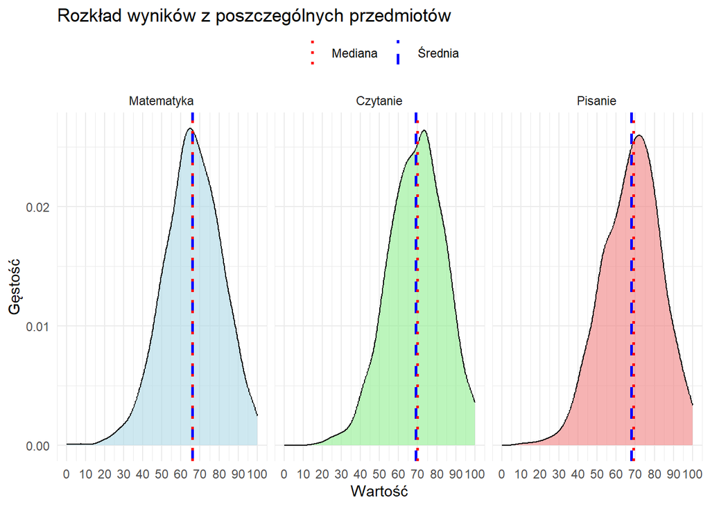

```r
# Obliczenie średniej i mediany dla każdego przedmiotu
summary_stats <- df %>%
  pivot_longer(cols = c("math.score", "reading.score", "writing.score"), names_to = "subject", values_to = "score") %>%
  group_by(subject) %>%
  summarise(
    mean_score = mean(score),
    median_score = median(score)
  )

# Stworzenie obiektu wykresu
plot1 <- df %>%
  pivot_longer(cols = c("math.score", "reading.score", "writing.score"), names_to = "subject", values_to = "score") %>%
  ggplot(aes(x = score, fill = subject)) +
  geom_density(alpha = 0.6) +
  facet_wrap(~subject, labeller = labeller(subject = c("math.score" = "Matematyka", "reading.score" = "Czytanie", "writing.score" = "Pisanie"))) +
  geom_vline(data = summary_stats, aes(xintercept = mean_score, color = "Średnia", linetype = "Średnia"), linewidth = 1) +
  geom_vline(data = summary_stats, aes(xintercept = median_score, color = "Mediana", linetype = "Mediana"), linewidth = 1) +
  scale_color_manual(values = c("Średnia" = "blue", "Mediana" = "red")) +
  scale_linetype_manual(values = c("Średnia" = "dashed", "Mediana" = "dotted")) +
  scale_x_continuous(breaks = seq(0, 100, by = 10)) +
  scale_fill_manual(guide = "none", values = c("math.score" = "lightblue", "reading.score" = "lightgreen", "writing.score" = "lightcoral")) +
  labs(title = "Rozkład wyników z poszczególnych przedmiotów",
       x = "Wartość",
       y = "Gęstość",
       color = NULL,
       linetype = NULL) +
  theme_minimal() +
  theme(legend.position = "top")

print(plot1)
```

**Rozklady są bardzo podobne i sbliżone do rozkladu normalnego. Są w pewnym stopniu lewostronnie skośne. Na wykresach widać, że dla Czytania i Pisania mediana (linia czerwona) jest nieco bardziej po prawej od średniej (linia niebieska), co potwierdza tę skośność. Mediana oraz Srednia wyników z czytania i pisania są wyższe niż z matematyki, co sugeruje, że uczniom generalnie łatwiej przychodziły zadania z przedmiotów humanistycznych.**

## Zadanie 2

Czy istnieje zauważalna różnica w wynikach między uczniami i uczennicami?

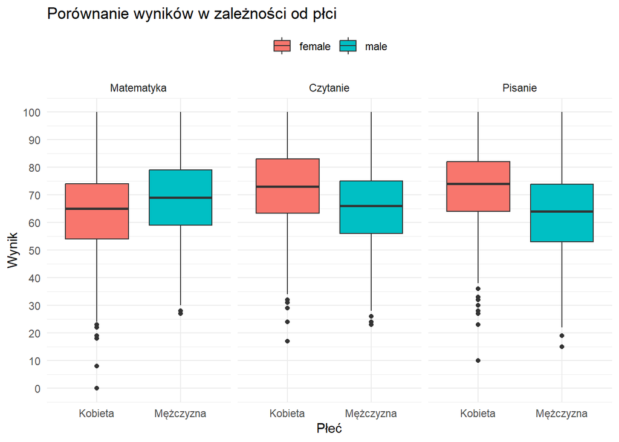

```r
plot2 <- df %>%
  pivot_longer(cols = c("math.score", "reading.score", "writing.score"), names_to = "subject", values_to = "score") %>%
  ggplot(aes(x = gender, y = score, fill = gender)) +
  geom_boxplot() +
  facet_wrap(~subject, labeller = labeller(subject = c("math.score" = "Matematyka", "reading.score" = "Czytanie", "writing.score" = "Pisanie"))) +
  scale_x_discrete(labels = c("female" = "Kobieta", "male" = "Mężczyzna")) +
  scale_y_continuous(breaks = seq(0, 100, by = 10)) +
  labs(title = "Porównanie wyników w zależności od płci",
       x = "Płeć",
       y = "Wynik",
       fill = NULL) +
  theme_minimal() +
  theme(legend.position = "top")

print(plot2)
```

**Widoczne są zauważalne różnice w wynikach egzaminu w zależności od płci. Meżczyzni(male) uzyskuja lepsze wyniki z matematyki, tymczasem kobiety(female) maja lepsze wyniki z czytania i pisania. Natomiast miedzykwartylowy odstep(IQR) jest podobny we wszystkich przypadkach. Outliery sa widoczne wszedzie ale w przypadku kobiet jest ich wiecej.**

## Zadanie 3

Czy uczniowie, którzy ukończyli kurs przygotowawczy, osiągają lepsze wyniki niż pozostali?

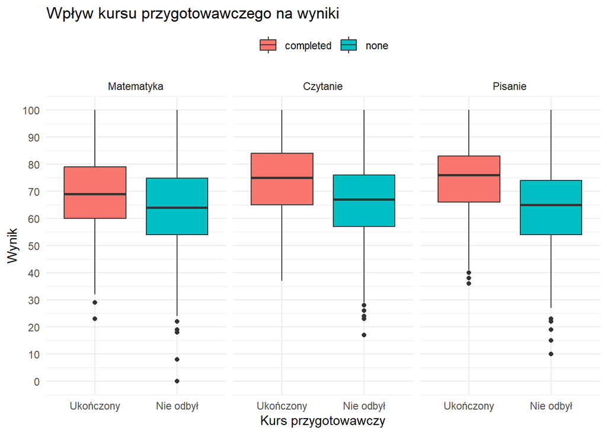

```r
plot3 <- df %>%
  pivot_longer(cols = c("math.score", "reading.score", "writing.score"), names_to = "subject", values_to = "score") %>%
  ggplot(aes(x = test.preparation.course, y = score, fill = test.preparation.course)) +
  geom_boxplot() +
  facet_wrap(~subject, labeller = labeller(subject = c("math.score" = "Matematyka", "reading.score" = "Czytanie", "writing.score" = "Pisanie"))) +
  scale_x_discrete(labels = c("completed" = "Ukończony", "none" = "Nie odbył")) +
  scale_y_continuous(breaks = seq(0, 100, by = 10)) +
  labs(title = "Wpływ kursu przygotowawczego na wyniki",
       x = "Kurs przygotowawczy",
       y = "Wynik",
       fill = NULL) +
  theme_minimal() +
  theme(legend.position = "top")

print(plot3)
```

**Zdecydowanie osiągają lepsze wyniki. Uczniowie, którzy ukończyli kurs przygotowawczy, osiągają wyraźnie wyższe mediany wyników we wszystkich trzech kategoriach w porównaniu do uczniów, którzy go nie odbyli. Natomiast najbardziej widoczne to jest w przypadku Czytania i Pisania, gdzie róznica pomiedzy medianami jest powyżej 8 punktów. Sugeruje to, że kurs przygotowawczy ma pozytywny wpływ na wyniki egzaminów.**

## Zadanie 4

Jaki jest związek między poziomem wykształcenia rodziców a średnimi wynikami uczniów?

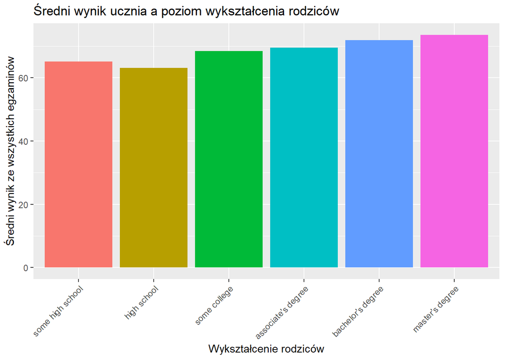

```r
plot4 <- df %>%
  mutate(average.score = (math.score + reading.score + writing.score) / 3) %>%
  group_by(parental.level.of.education) %>%
  summarise(mean.avg.score = mean(average.score)) %>%
  mutate(parental.level.of.education = factor(parental.level.of.education,
                                              levels = c("some high school", "high school", "some college",
                                                         "associate's degree", "bachelor's degree", "master's degree"))) %>%
  ggplot(aes(x = parental.level.of.education, y = mean.avg.score, fill = parental.level.of.education)) +
  geom_bar(stat = "identity") +
  labs(title = "Średni wynik ucznia a poziom wykształcenia rodziców",
       x = "Wykształcenie rodziców",
       y = "Średni wynik ze wszystkich egzaminów") +
  theme(axis.text.x = element_text(angle = 45, hjust = 1), legend.position = "none")

print(plot4)
```

## Zadanie 5

Czy płeć i wykształcenie rodzica wpływa na wynik z matematyki?

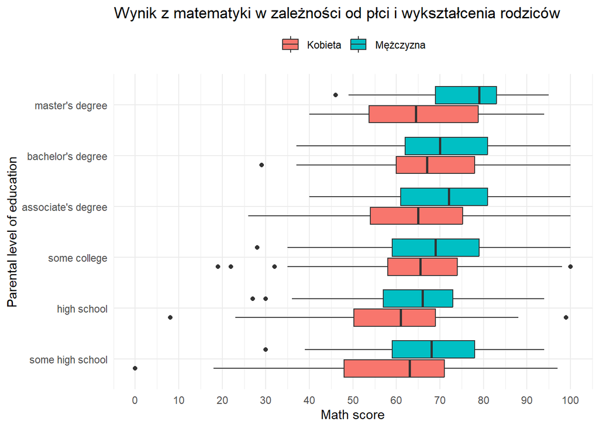

```r
plot5 <- df %>%
  mutate(parental.level.of.education = factor(parental.level.of.education,
                                              levels = c("some high school", "high school", "some college",
                                                         "associate's degree", "bachelor's degree", "master's degree"))) %>%
  ggplot(aes(x = parental.level.of.education, y = math.score, fill = gender)) +
  geom_boxplot() +
  scale_y_continuous(breaks = seq(0, 100, by = 10)) +
  scale_fill_discrete(labels = c("female" = "Kobieta", "male" = "Mężczyzna")) +
  labs(title = "Wynik z matematyki w zależności od płci i wykształcenia rodziców",
       x = "Parental level of education",
       y = "Math score",
       fill = NULL) +
  coord_flip() +
  theme_minimal() +
  theme(legend.position = "top")

print(plot5)
```

## Zadanie 6

Czy istnieje zależność między wynikami z matematyki a wynikami z czytania lub pisania?

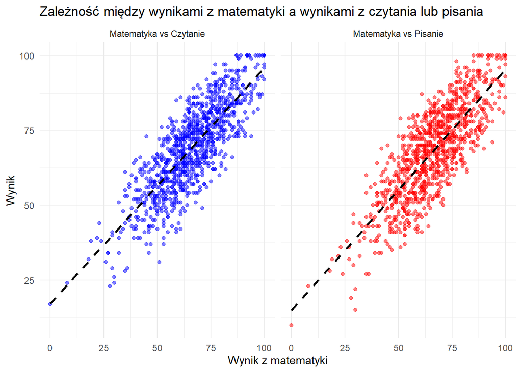

```r
df_long <- df %>%
  pivot_longer(cols = c("reading.score", "writing.score"),
               names_to = "subject",
               values_to = "score") %>%
  mutate(subject = factor(subject,
                          levels = c("reading.score", "writing.score"),
                          labels = c("Czytanie", "Pisanie")))

plot6 <- ggplot(df_long, aes(x = math.score, y = score)) +
  geom_point(aes(color = subject), alpha = 0.5) +
  geom_smooth(method = "lm", fill = NA, color = "black", formula = y ~ x, linetype = "dashed") +
  facet_wrap(~subject, labeller = labeller(subject = c("Czytanie" = "Matematyka vs Czytanie", "Pisanie" = "Matematyka vs Pisanie"))) +
  scale_color_manual(values = c("Czytanie" = "blue", "Pisanie" = "red"), guide = "none") +
  labs(title = "Zależność między wynikami z matematyki a wynikami z czytania lub pisania",
       x = "Wynik z matematyki",
       y = "Wynik") +
  theme_minimal()

print(plot6)
```

**Widoczna jest silna dodatnia korelacja liniowa(Pearsona) między wynikami z matematyki a wynikami z czytania oraz pisania. Oznacza to, że uczniowie, którzy dobrze radzą sobie z matematyką, mają również tendencję do osiągania wysokich wyników z czytania i pisania. Chmury punktów są gęsto skupione wokół linii regresji, co potwierdza siłę tej zależności.**